# Feature Selection Methods

In this note, we will examine the following set of methods for feature selection.

- Theory: Use published literature or domain knowledge to pick variables.
- Filter Methods: Keep predictors that are relevant but not redundant.
- Subset Selection: Identify a subset of p predictors that are related to the outcome. Fit a model with this subset.
- Shrinkage Methods: Fit a model with all p predictors, but the estimated coefficients are shrunken towards zero relative to least squares estimates. This shrinkage (also known as regularization) has the effect of reducing variance and can also perform variable selection.
- Dimension reduction: Group predictors into a reduced number of components based on similarity. Use the components as predictors.

## Data

In order to illustrate feature selection methods, we will use a wine dataset. In this dataset, a set of White Wines are characterized by chemical properties measured on eleven variables. The quality of each wine is evaluated by sensory tests by wine experts.

- fixed acidity
- volatile acidity
- citric acid
- residual sugar
- chlorides
- free sulfur dioxide
- total sulfur dioxide
- density
- pH
- sulphates
- alcohol

## Read Data

```python
import pandas as pd
import numpy as np
wine = pd.read_csv('winequality-white.csv',sep=';')
wine.columns = wine.columns.str.replace(' ', '_')
```

## Split Data

```python
from sklearn.model_selection import train_test_split
X = wine.drop(['quality'], axis=1)
y = wine.quality
X_train, X_test, y_train, y_test = train_test_split(X,
                                                    y,
                                                    test_size=0.3,
                                                    random_state=1031)
```

## Theory

The choice of features to include in a model should be guided by existing knowledge of the domain. Only features that would be expected to influence the outcome variable should be candidates for inclusion in the model. The expectation of a relationship may be based on a theory, domain knowledge, or expert opinion. This should always be the first line of attack for feature selection. It is unfortunate that with the availability of large datasets and powerful analytical techniques, this method is often overlooked.

## Filter Methods

Screen predictors based on their relationship to the outcome variable (relevance) and to other predictors (redundancy) thereby retaining variables that are relevant and non-redundant.

- Relevant: Related to the outcome variable, and
- Non-redundant: Not related to other predictors

### Bivariate Filter

A simple method for screening predictors is by examining their bivariate correlations.

- Relevant: High bivariate correlation with outcome
- Non-redundant: Low bivariate correlation with other predictors

Then, select variables that have high correlations with the outcome (e.g., |r| > 0.2) and low correlations with other predictors (e.g., all |r|<0.4).

A correlation matrix tabulates all pairwise correlations among variables in a dataset. With a large number of features, a correlation heatmap can help identify relevant and non-redundant variables.

```python
wine_train = X_train.copy()
wine_train['quality'] = y_train
wine_train.corr().round(2)
# wine_train.corr().round(2)['quality'] # to see only relevant predictors
# wine_train.corr().round(2).drop('quality', axis = 1) # to see only relevant predictors
```

|  | fixed_acidity | volatile_acidity | citric_acid | residual_sugar | chlorides | free_sulfur_dioxide | total_sulfur_dioxide | density | pH | sulphates | alcohol | quality |
| --- | --- | --- | --- | --- | --- | --- | --- | --- | --- | --- | --- | --- |
| fixed_acidity | 1.00 | -0.01 | 0.29 | 0.08 | 0.02 | -0.05 | 0.10 | 0.27 | -0.42 | -0.00 | -0.12 | -0.12 |
| volatile_acidity | -0.01 | 1.00 | -0.15 | 0.05 | 0.07 | -0.11 | 0.08 | 0.01 | -0.04 | -0.04 | 0.07 | -0.19 |
| citric_acid | 0.29 | -0.15 | 1.00 | 0.11 | 0.13 | 0.09 | 0.13 | 0.16 | -0.17 | 0.06 | -0.08 | -0.02 |
| residual_sugar | 0.08 | 0.05 | 0.11 | 1.00 | 0.07 | 0.30 | 0.41 | 0.83 | -0.19 | -0.02 | -0.46 | -0.09 |
| chlorides | 0.02 | 0.07 | 0.13 | 0.07 | 1.00 | 0.09 | 0.18 | 0.24 | -0.09 | 0.01 | -0.35 | -0.20 |
| free_sulfur_dioxide | -0.05 | -0.11 | 0.09 | 0.30 | 0.09 | 1.00 | 0.62 | 0.30 | -0.00 | 0.08 | -0.24 | 0.02 |
| total_sulfur_dioxide | 0.10 | 0.08 | 0.13 | 0.41 | 0.18 | 0.62 | 1.00 | 0.54 | 0.00 | 0.15 | -0.44 | -0.16 |
| density | 0.27 | 0.01 | 0.16 | 0.83 | 0.24 | 0.30 | 0.54 | 1.00 | -0.09 | 0.07 | -0.80 | -0.31 |
| pH | -0.42 | -0.04 | -0.17 | -0.19 | -0.09 | -0.00 | 0.00 | -0.09 | 1.00 | 0.15 | 0.12 | 0.11 |
| sulphates | -0.00 | -0.04 | 0.06 | -0.02 | 0.01 | 0.08 | 0.15 | 0.07 | 0.15 | 1.00 | -0.01 | 0.06 |
| alcohol | -0.12 | 0.07 | -0.08 | -0.46 | -0.35 | -0.24 | -0.44 | -0.80 | 0.12 | -0.01 | 1.00 | 0.43 |
| quality | -0.12 | -0.19 | -0.02 | -0.09 | -0.20 | 0.02 | -0.16 | -0.31 | 0.11 | 0.06 | 0.43 | 1.00 |

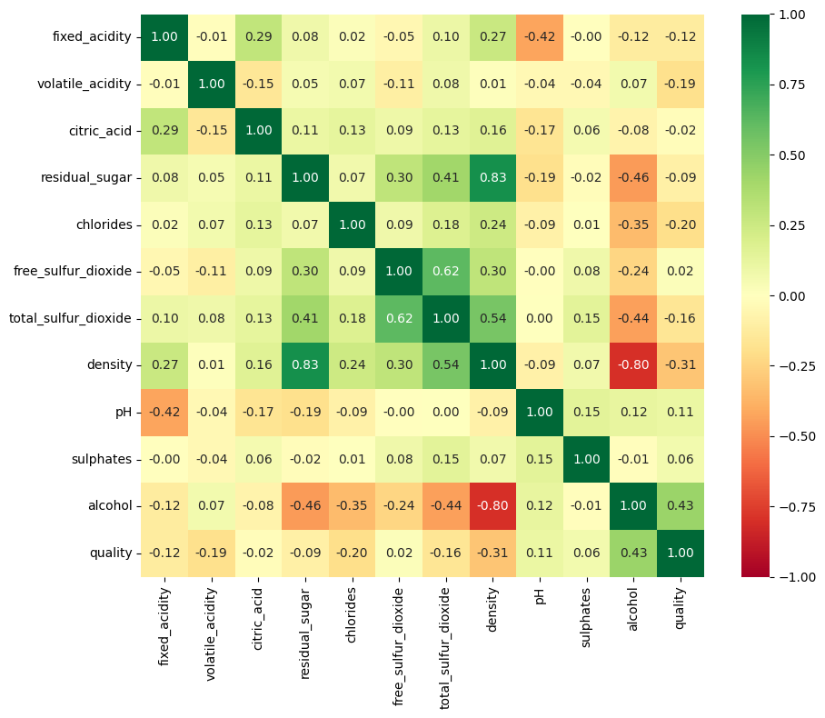

```python
import seaborn as sns
import matplotlib.pyplot as plt
plt.figure(figsize=(10, 8))
sns.heatmap(wine_train.corr(),
            annot=True,
            fmt=".2f",
            cmap="RdYlGn",
            vmin=-1,
            vmax=1,
            square=True)
plt.tight_layout()
plt.show()
```

## Multivariate Filter

We will examine relevance and redundancy of predictors of all predictors together. Reason for this is that often what is true in pairwise relationships may not be found when all predictors are considered together. Specifically, predictors found to be relevant and non-redundant based on bivariate correlations may be found to be redundant when effects of other predictors are accounted for. To see if this is the case, we will examine statistical significance of regression coefficients and variance inflating factor.

### Coefficients

```python
from statsmodels.formula.api import ols
reg = ols('quality~fixed_acidity + volatile_acidity + citric_acid + residual_sugar + chlorides + free_sulfur_dioxide + total_sulfur_dioxide + density + pH + sulphates + alcohol',
    data=wine_train)
reg.fit().summary()
```

OLS Regression Results

| Dep. Variable: | quality | R-squared: | 0.277 |
| --- | --- | --- | --- |
| Model: | OLS | Adj. R-squared: | 0.274 |
| Method: | Least Squares | F-statistic: | 118.7 |
| Date: | Wed, 05 Nov 2025 | Prob (F-statistic): | 1.33e-230 |
| Time: | 23:56:27 | Log-Likelihood: | -3879.7 |
| No. Observations: | 3428 | AIC: | 7783. |
| Df Residuals: | 3416 | BIC: | 7857. |
| Df Model: | 11 |  |  |
| Covariance Type: | nonrobust |  |  |

|  | coef | std err | t | P>\|t\| | [0.025 | 0.975] |
| --- | --- | --- | --- | --- | --- | --- |
| Intercept | 194.0322 | 27.448 | 7.069 | 0.000 | 140.215 | 247.849 |
| fixed_acidity | 0.1019 | 0.028 | 3.654 | 0.000 | 0.047 | 0.157 |
| volatile_acidity | -1.8070 | 0.136 | -13.289 | 0.000 | -2.074 | -1.540 |
| citric_acid | -0.0459 | 0.114 | -0.403 | 0.687 | -0.269 | 0.177 |
| residual_sugar | 0.0957 | 0.010 | 9.240 | 0.000 | 0.075 | 0.116 |
| chlorides | 0.2178 | 0.642 | 0.339 | 0.734 | -1.041 | 1.477 |
| free_sulfur_dioxide | 0.0034 | 0.001 | 3.433 | 0.001 | 0.001 | 0.005 |
| total_sulfur_dioxide | 3.497e-05 | 0.000 | 0.076 | 0.939 | -0.001 | 0.001 |
| density | -194.8589 | 27.820 | -7.004 | 0.000 | -249.405 | -140.312 |
| pH | 0.8807 | 0.136 | 6.488 | 0.000 | 0.615 | 1.147 |
| sulphates | 0.6923 | 0.122 | 5.671 | 0.000 | 0.453 | 0.932 |
| alcohol | 0.1387 | 0.035 | 3.988 | 0.000 | 0.071 | 0.207 |

| Omnibus: | 85.730 | Durbin-Watson: | 1.942 |
| --- | --- | --- | --- |
| Prob(Omnibus): | 0.000 | Jarque-Bera (JB): | 201.350 |
| Skew: | -0.013 | Prob(JB): | 1.89e-44 |
| Kurtosis: | 4.187 | Cond. No. | 4.57e+05 |

Notes:  
[1] Standard Errors assume that the covariance matrix of the errors is correctly specified.  
[2] The condition number is large, 4.57e+05. This might indicate that there are  
strong multicollinearity or other numerical problems.

### Variance Inflation Factor (VIF)

VIF assesses threat of multicollinearity.

- No multicollinearity: VIF = 1
- Acceptable: 1 < VIF <= 5
- Potentially problematic: 5 < VIF <= 10
- Serious multicollinearity: VIF>10

```python
from statsmodels.stats.outliers_influence import variance_inflation_factor
from statsmodels.api import add_constant
X_with_const = add_constant(X_train)

vif_data = pd.DataFrame()
vif_data["feature"] = X_with_const.columns
vif_data["VIF"] = [variance_inflation_factor(X_with_const.values, i)
                   for i in range(X_with_const.shape[1])]

vif_data.sort_values('VIF',ascending=False)
```

|  | feature | VIF |
| --- | --- | --- |
| 0 | const | 4.570781e+06 |
| 8 | density | 3.973410e+01 |
| 4 | residual_sugar | 1.629447e+01 |
| 11 | alcohol | 1.093458e+01 |
| 1 | fixed_acidity | 3.277995e+00 |
| 9 | pH | 2.539471e+00 |
| 7 | total_sulfur_dioxide | 2.348395e+00 |
| 6 | free_sulfur_dioxide | 1.826211e+00 |
| 5 | chlorides | 1.239078e+00 |
| 3 | citric_acid | 1.176657e+00 |
| 10 | sulphates | 1.160120e+00 |
| 2 | volatile_acidity | 1.136998e+00 |

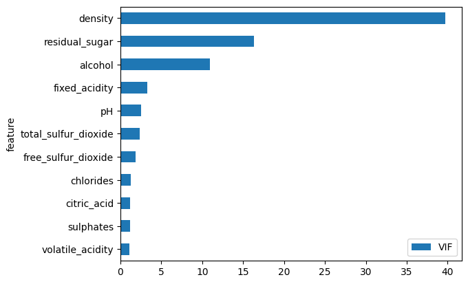

```python
vif_data.sort_values('VIF',ascending=True).drop(0,axis=0).plot(x='feature',y='VIF', kind = 'barh')
plt.show()
```

## Subset Selection

Feature selection can be automated by using subset selection methods. Stepwise variable selection methods pick features in a computationally efficient manner while best subset selection methods takes on a brute force approach by examining all combinations of features.

### Stepwise Variable Selection

Features are introduced into a regression model one at a time. There are three methods that differ in the way features are introduced into the model.

- Forward: Beginning with an intercept-only model, features are added to the model in order of predictive power. Process stops when the marginal improvement in the model from adding another feature is below a threshold or non-significant.
- Backward: Beginning with a saturated model, features are removed from the model in order of impact on model performance. Features with less impact are removed first. Process stops when removal of a feature would cause change in performance to drop below a threshold or a statistically significant worsening in performance.
- Stepwise: This method combines Forward and Backward methods, adding and subtracting features. Begins with an intercept-only model.

#### Forward

- Set forward = True, and floating = False

```python
from mlxtend.feature_selection import SequentialFeatureSelector
from sklearn.linear_model import LinearRegression
sfs = SequentialFeatureSelector(LinearRegression(),
                                  k_features='best',
                                  forward=True,
                                  floating=False,
                                  scoring='r2',
                                  cv=5)
sfs = sfs.fit(X_train, y_train)
pd.DataFrame(sfs.get_metric_dict()).T.loc[:,['feature_names','avg_score']].sort_values('avg_score', ascending = False)
```

|  | feature_names | avg_score |
| --- | --- | --- |
| 8 | (fixed_acidity, volatile_acidity, residual_sug... | 0.267037 |
| 9 | (fixed_acidity, volatile_acidity, residual_sug... | 0.26688 |
| 10 | (fixed_acidity, volatile_acidity, citric_acid,... | 0.266418 |
| 11 | (fixed_acidity, volatile_acidity, citric_acid,... | 0.265909 |
| 7 | (fixed_acidity, volatile_acidity, residual_sug... | 0.258087 |
| 6 | (fixed_acidity, volatile_acidity, residual_sug... | 0.256356 |
| 5 | (fixed_acidity, volatile_acidity, residual_sug... | 0.253449 |
| 4 | (volatile_acidity, residual_sugar, free_sulfur... | 0.250115 |
| 3 | (volatile_acidity, residual_sugar, alcohol) | 0.245237 |
| 2 | (volatile_acidity, alcohol) | 0.22771 |
| 1 | (alcohol,) | 0.180633 |

```python
sfs.k_feature_names_
```

```
('fixed_acidity',
 'volatile_acidity',
 'residual_sugar',
 'free_sulfur_dioxide',
 'density',
 'pH',
 'sulphates',
 'alcohol')
```

#### Backward

- Set forward= False, and floating = False

```python
from mlxtend.feature_selection import SequentialFeatureSelector
from sklearn.linear_model import LinearRegression
sfs = SequentialFeatureSelector(LinearRegression(),
          k_features='best',
          forward=False,
          floating=False,
          scoring='r2',
          cv=5)
sfs = sfs.fit(X_train, y_train)
pd.DataFrame(sfs.get_metric_dict()).T.loc[:,['feature_names','avg_score']].sort_values('avg_score', ascending = False)
```

|  | feature_names | avg_score |
| --- | --- | --- |
| 8 | (fixed_acidity, volatile_acidity, residual_sug... | 0.267037 |
| 9 | (fixed_acidity, volatile_acidity, residual_sug... | 0.26688 |
| 10 | (fixed_acidity, volatile_acidity, citric_acid,... | 0.266418 |
| 11 | (fixed_acidity, volatile_acidity, citric_acid,... | 0.265909 |
| 7 | (volatile_acidity, residual_sugar, free_sulfur... | 0.264212 |
| 6 | (volatile_acidity, residual_sugar, density, pH... | 0.261673 |
| 5 | (volatile_acidity, residual_sugar, density, pH... | 0.255732 |
| 4 | (volatile_acidity, residual_sugar, pH, alcohol) | 0.248947 |
| 3 | (volatile_acidity, residual_sugar, alcohol) | 0.245237 |
| 2 | (volatile_acidity, alcohol) | 0.22771 |
| 1 | (alcohol,) | 0.180633 |

```python
sfs.k_feature_names_
```

```
('fixed_acidity',
 'volatile_acidity',
 'residual_sugar',
 'free_sulfur_dioxide',
 'density',
 'pH',
 'sulphates',
 'alcohol')
```

#### Stepwise

- Set forward = True, and floating = True

```python
from mlxtend.feature_selection import SequentialFeatureSelector
from sklearn.linear_model import LinearRegression
sfs = SequentialFeatureSelector(LinearRegression(),
          k_features='best',
          forward=True,
          floating=True,
          scoring='r2',
          cv=5)
sfs = sfs.fit(X_train, y_train)
pd.DataFrame(sfs.get_metric_dict()).T.loc[:,['feature_names','avg_score']].sort_values('avg_score', ascending = False)
```

|  | feature_names | avg_score |
| --- | --- | --- |
| 8 | (fixed_acidity, volatile_acidity, residual_sug... | 0.267037 |
| 9 | (fixed_acidity, volatile_acidity, residual_sug... | 0.26688 |
| 10 | (fixed_acidity, volatile_acidity, citric_acid,... | 0.266418 |
| 11 | (fixed_acidity, volatile_acidity, citric_acid,... | 0.265909 |
| 7 | (volatile_acidity, residual_sugar, free_sulfur... | 0.264212 |
| 6 | (volatile_acidity, residual_sugar, free_sulfur... | 0.258128 |
| 5 | (fixed_acidity, volatile_acidity, residual_sug... | 0.253449 |
| 4 | (volatile_acidity, residual_sugar, free_sulfur... | 0.250115 |
| 3 | (volatile_acidity, residual_sugar, alcohol) | 0.245237 |
| 2 | (volatile_acidity, alcohol) | 0.22771 |
| 1 | (alcohol,) | 0.180633 |

```python
sfs.k_feature_names_
```

```
('fixed_acidity',
 'volatile_acidity',
 'residual_sugar',
 'free_sulfur_dioxide',
 'density',
 'pH',
 'sulphates',
 'alcohol')
```

### Best Subset Selection

These methods work by examining all possible subsets.

```python
from mlxtend.feature_selection import ExhaustiveFeatureSelector
from sklearn.linear_model import LinearRegression
efs = ExhaustiveFeatureSelector(LinearRegression(),
                                min_features=1,
                                max_features = 11,
                                print_progress=True,
                                scoring = 'r2',
                                cv=5)
efs = efs.fit(X_train, y_train)
pd.DataFrame(efs.get_metric_dict()).T.loc[:,['feature_names','avg_score']].sort_values('avg_score', ascending = False)
```

```
Features: 2047/2047
```

|  | feature_names | avg_score |
| --- | --- | --- |
| 1890 | (fixed_acidity, volatile_acidity, residual_sug... | 0.267037 |
| 2012 | (fixed_acidity, volatile_acidity, residual_sug... | 0.26688 |
| 1999 | (fixed_acidity, volatile_acidity, citric_acid,... | 0.266556 |
| 2014 | (fixed_acidity, volatile_acidity, residual_sug... | 0.266494 |
| 2039 | (fixed_acidity, volatile_acidity, citric_acid,... | 0.266418 |
| ... | ... | ... |
| 163 | (citric_acid, free_sulfur_dioxide, sulphates) | -0.000905 |
| 54 | (free_sulfur_dioxide, sulphates) | -0.001088 |
| 2 | (citric_acid,) | -0.004164 |
| 32 | (citric_acid, free_sulfur_dioxide) | -0.00468 |
| 5 | (free_sulfur_dioxide,) | -0.004705 |

2047 rows × 2 columns

```python
efs.best_feature_names_
```

```
('fixed_acidity',
 'volatile_acidity',
 'residual_sugar',
 'free_sulfur_dioxide',
 'density',
 'pH',
 'sulphates',
 'alcohol')
```

## Shrinkage

Shrinkage methods constrain or regularize coefficient estimates, or equivalently, shrink the coefficient estimates towards zero. Based on the shrinkage penalty used, there are two shrinkage methods, Ridge regression and Lasso. The shrinkage penalty in Ridge regression suppresses all coefficients, on the other hand, the penalty in Lasso has the effect of forcing some, not all, coefficient estimates to be exactly zero. By forcing only some coefficient estimate to zero, Lasso in essence performs feature selection.

With shrinkage methods, it is a good practice to standardize variables, so we begin by doing that.

```python
from sklearn.preprocessing import StandardScaler
scale = StandardScaler()
scale.fit(X_train)
X_train_scaled = scale.transform(X_train)
X_test_scaled = scale.transform(X_test)
```

### Shrinkage Methods

- Implemented using ElasticNet
- Determining regularization parameter alpha is hard. ElasticNetCV uses cross-validation to examine a series of values of alpha.
- For lasso, l1_ratio = 1. For ridge regression, l1_ratio = 0.

```python
from sklearn.linear_model import ElasticNet, ElasticNetCV
lasso = ElasticNetCV(l1_ratio=1,
                     cv=5,
                     random_state=1031)
lasso.fit(X_train_scaled, y_train)
best_alpha = lasso.alpha_
print('The best alpha is', best_alpha)
```

```
The best alpha is 0.0007618482984559628
```

```python
lasso.coef_
```

```
array([ 0.07249511, -0.18159976, -0.0045665 ,  0.44806669,  0.00155619,
        0.05971874, -0.        , -0.51990445,  0.12298285,  0.07532625,
        0.1898886 ])
```

```python
pd.DataFrame(lasso.coef_,columns=['lasso coefficients']).set_index(X_train.columns)
```

|  | lasso coefficients |
| --- | --- |
| fixed_acidity | 0.072495 |
| volatile_acidity | -0.181600 |
| citric_acid | -0.004567 |
| residual_sugar | 0.448067 |
| chlorides | 0.001556 |
| free_sulfur_dioxide | 0.059719 |
| total_sulfur_dioxide | -0.000000 |
| density | -0.519904 |
| pH | 0.122983 |
| sulphates | 0.075326 |
| alcohol | 0.189889 |

```python
alphas = lasso.alphas_
mse_path = lasso.mse_path_
mean_mse = np.mean(mse_path, axis=1)
std_mse = np.std(mse_path, axis=1)
```

#### Visualize Effect of Changing Alpha

Dotted red line indicates optimal alpha chosen by ElasticNetCV.

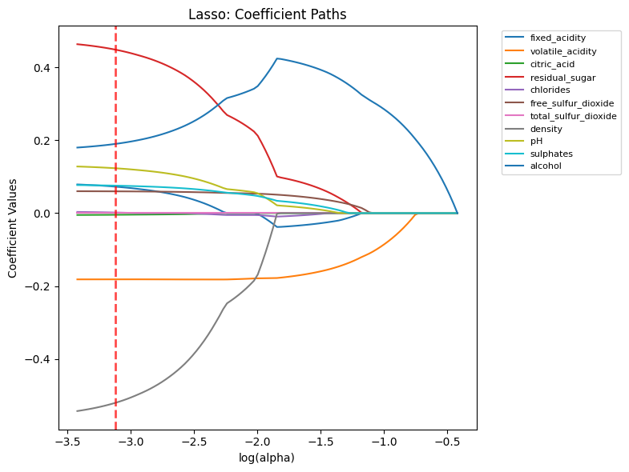

```python
plt.figure(figsize=(8, 6))
feature_names = X_train.columns
coef_paths = []
for alpha in alphas:
    lasso_temp = ElasticNet(l1_ratio=1, alpha=alpha, random_state=1031, max_iter=2000)
    lasso_temp.fit(X_train_scaled, y_train)
    coef_paths.append(lasso_temp.coef_)
coef_paths = np.array(coef_paths)
# Plot of coefficient paths
for i, feature in enumerate(feature_names):
    plt.plot(np.log10(alphas), coef_paths[:, i], label=feature, linewidth=1.5)
plt.axvline(x=np.log10(best_alpha), color='red', linestyle='--', alpha=0.7, linewidth=2)
plt.xlabel('log(alpha)')
plt.ylabel('Coefficient Values')
plt.title('Lasso: Coefficient Paths')
plt.legend(bbox_to_anchor=(1.05, 1), loc='upper left', fontsize=8)
plt.tight_layout()
plt.show()
```

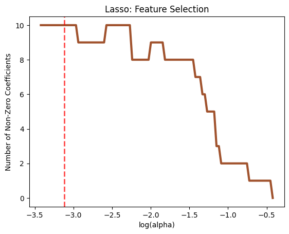

```python
# Plot of number of non-zero coefficients vs alpha
non_zero_counts = np.sum(coef_paths != 0, axis=1)
plt.plot(np.log10(alphas), non_zero_counts, 'sienna', linewidth=3)
plt.axvline(x=np.log10(best_alpha), color='red', linestyle='--', alpha=0.7, linewidth=2)
plt.xlabel('log(alpha)')
plt.ylabel('Number of Non-Zero Coefficients')
plt.title('Lasso: Feature Selection')
plt.show()
```

## Dimension Reduction

In this approach, p predictors are reduced to a smaller number of components based on a measure of similarity (e.g., correlation). Here, we will examine a popular dimension reduction technique called Principal Components Analysis (PCA).

PCA is senstive to scale of the data, so we will use standardized features. Principal components analysis will always generate as many components as variables. The first few components contain the most amount of variance. One heuristic for number of components to retain is a cumulative variance greater than 70%. In this case, we are extracting only five of eleven components.

```python
from sklearn.decomposition import PCA
pca = PCA(n_components=5)
pca.fit(X_train_scaled)
X_train_pc = pca.transform(X_train_scaled)
X_test_pc =  pca.transform(X_test_scaled)
X_train_pc
```

```
array([[-0.6351008 , -1.53094122,  0.76911674,  4.89703295, -0.405477  ],
       [ 2.26844888, -1.55666487,  0.89818634, -0.70915726, -1.53108657],
       [ 1.31685614, -0.53855171, -0.73444566,  0.33361523, -0.52027253],
       ...,
       [ 0.8019643 ,  1.50280166,  1.07443231, -0.74208311,  0.40968636],
       [ 1.18977299,  2.0325778 , -0.65920222, -0.21492415, -0.05507088],
       [ 1.03016018,  0.33972773,  0.61365436,  0.27331317,  0.9521514 ]],
      shape=(3428, 5))
```

```python
import numpy as np
np.sum(pca.explained_variance_ratio_)
```

```
np.float64(0.7315261574501754)
```

```python
from sklearn.linear_model import LinearRegression
reg = LinearRegression()
reg.fit(X_train_pc, y_train)
pred_test = reg.predict(X_test_pc)
```

```python
from sklearn.metrics import root_mean_squared_error
root_mean_squared_error(y_test, pred_test)
```

```
0.8030092005078765
```

## Summary

In this note, we examined a set of feature selection methods

- Theory
- Filter Methods
- Subset Selection
- Shrinkage (with Lasso)
- Dimension Reduction (using PCA)

This file was generated using Python 3.13.5 on Windows 10 with the following libraries: matplotlib 3.10.3, mlxtend 0.23.4, numpy 2.3.1, pandas 2.3.0, scikit-learn 1.7.1, seaborn 0.13.2, statsmodels 0.14.5